# Reading, summarizing and plotting data and performing 1-sample t-test

### Problem 1:

Hand computation. You may use R to compute the mean and the standard deviations

### Problem 2:

First open the file using notepad or similar app (on windows OS I like notepad++, you have to install it). Notice that the first line in the file is a text giving the name of the variable. in R, this is known as a “header” In order to read a data file that is not comma seprated, we use the function *read.table* . Because a header is present we will set the “header” argument to TRUE so that R knows the first line contains the name, not an observation. In order to check if R read the data correctly, we print characteristic of the data using the function “str”

```r
mydata = read.table("cholBaylor.txt",header = T)
str(mydata)
```

```
## 'data.frame':    71 obs. of  1 variable:
##  $ Cholesterol: num  174 186 160 181 202 ...
```

It seems that R read the data correctly, the data-frame named mydata has a variable named “Cholesterol” which is of type numeric (“num” i.e. continuous variable). The individual variables in a data-frame can be accessed by using a “$” syntax. For example, we are going to compute the sample mean and the sample s.d. of the variable Cholesterol:

```r
mean(mydata$Cholesterol)
```

```
## [1] 171.4437
```

```r
sd(mydata$Cholesterol)
```

```
## [1] 25.53437
```

In order to draw a histogram and box-plot of the data we will use the package “ggplot2”. If this package is not installed (i.e. if you get an error message in the following command) you can install it by going to Rstudio’s Tools –> Install Packages menu and entering ggplot2. Note: this is one time deal on your laptop, unless you update R)

```r
library("ggplot2")
```

To obtain the histogram:

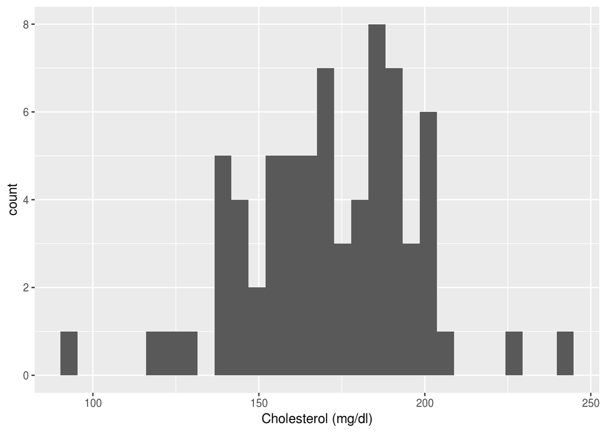

```r
ggplot(data=mydata, aes(x=Cholesterol)) + geom_histogram() + xlab("Cholesterol (mg/dl)")
```

To obtain a box-plot

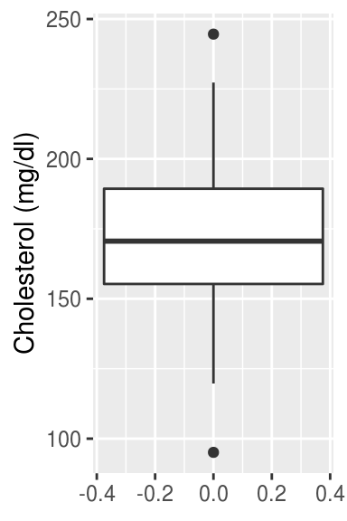

```r
ggplot(data=mydata, aes(y=Cholesterol)) + geom_boxplot() + ylab("Cholesterol (mg/dl)")
```

Both the histogram and the box-plot indicate that the data is quite symmetrically distributed about the mean. The histogram also reveals 3 potential outliers, and the boxplot reveals two potential outliers.

Suppose $\mu$ denote the population average of cholesterol levels of the sedentary female undergraduates in Baylor university. We want to test if $H_0:\mu=168$ vs $H_A:\mu\ne168.$

In order to compute the t-statistic (a.k.a t-ratio) we use the command “t.test”: The first argument is a single vector of observations that tells R we want to do a one-sample t-test, the other argument “mu=168” tells R that we want to test against “mu=168”

```r
t.test(mydata$Cholesterol, mu = 168)
```

```
##
##  One Sample t-test
##
## data:  mydata$Cholesterol
## t = 1.1364, df = 70, p-value = 0.2597
## alternative hypothesis: true mean is not equal to 168
## 95 percent confidence interval:
##  165.3998 177.4875
## sample estimates:
## mean of x
##  171.4437
```

As you can see, the t-ratio is 1.1364 with $n-1$ = 70 degrees of freedom. The p-value is 0.2597 and gives no evidence against the null hypothesis.

Conclusion: There’s no evidence that the mean cholesterol level of the sedentary university female undergraduates in Baylor university is different from 168.

### Problem 3

In order to read a csv file use the command “read.csv”. By the way, unlike “read.table”, read.csv expects a header by default. In this dataset, a header is present so all is well (if a header is not present you need to pass “header=F” to read.csv; F stands for FALSE)

```r
deely = read.csv("deely.csv")
```

Try to do the rest yourself. The code is given below.

```r
mean(deely$conc)
```

```
## [1] 0.84063
```

```r
sd(deely$conc)
```

```
## [1] 0.007823618
```

With only 10 observations the histogram and box-plots are not much useful, but they allow you to see if there’s any weird (and wrong) observation present in the data.

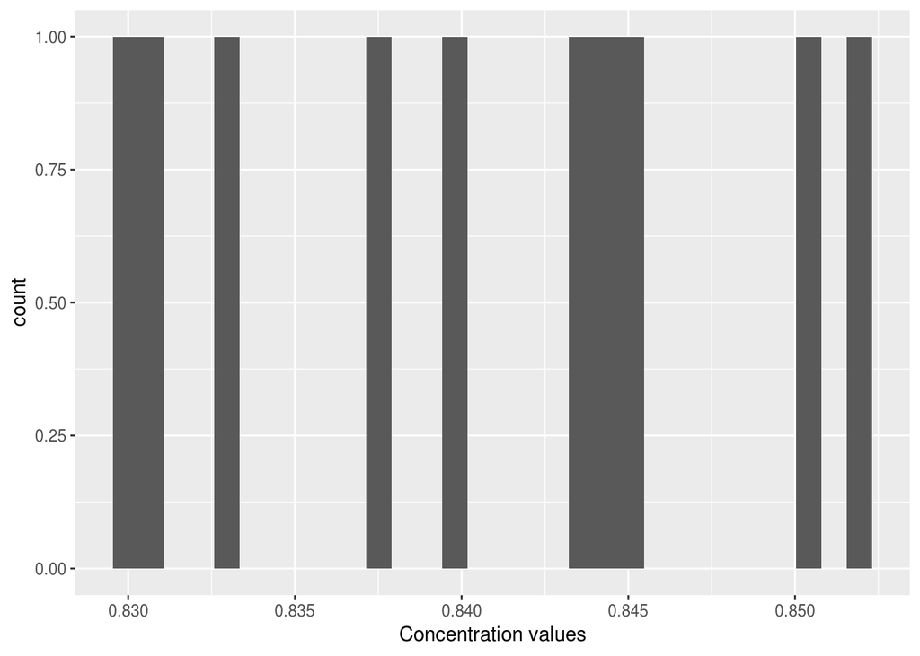

```r
ggplot(data=deely, aes(x=conc)) + geom_histogram() + xlab("Concentration values")
```

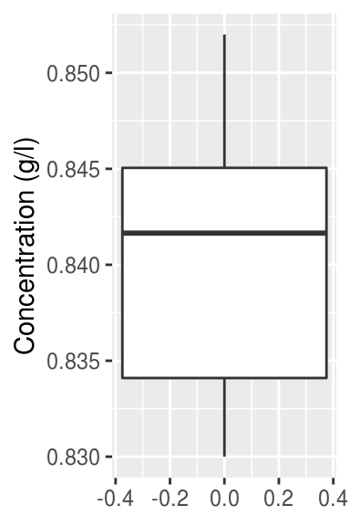

```r
ggplot(data=deely, aes(y=conc)) + geom_boxplot() + ylab("Concentration (g/l)")
```

```r
t.test(deely$conc, mu = 0.86)
```

```
##
##  One Sample t-test
##
## data:  deely$conc
## t = -7.8293, df = 9, p-value = 2.629e-05
## alternative hypothesis: true mean is not equal to 0.86
## 95 percent confidence interval:
##  0.8350333 0.8462267
## sample estimates:
## mean of x
##   0.84063
```

Note that the p-value < 0.0001 gives very strong evidence against the null hypothesis.

Conclusion: There is strong evidence in the data that the concentration of the active ingredient is significantly less (because the sample mean is smaller than 0.86) than 0.86g/l.